# IE 582 - HW 1 - Barış Işık - 2018702069

```python
import pandas as pd
from IPython.core.display import display, HTML
display(HTML("<style>.container { width:95% !important; }</style>"))
```

```python
Matches = pd.read_csv("matches.csv")
Stats = pd.read_csv("stats.csv")
Goals = pd.read_csv("goals.csv")
Booking = pd.read_csv("booking.csv")
Bets = pd.read_csv("bets.csv")
```

Let's check the first 5 rows of data frames and keep them there. I like to see column names and contents when I need to concrete it in my mind.

```python
Matches.head()
```

|  | match_awayteam_id | match_hometeam_id | match_id | epoch | match_status | match_live | match_hometeam_name | match_awayteam_name | match_hometeam_score | match_awayteam_score | match_hometeam_halftime_score | match_awayteam_halftime_score | match_hometeam_extra_score | match_awayteam_extra_score | match_hometeam_penalty_score | match_awayteam_penalty_score | league_id |
| --- | --- | --- | --- | --- | --- | --- | --- | --- | --- | --- | --- | --- | --- | --- | --- | --- | --- |
| 0 | 7109 | 7097 | 41196 | 1505559600 | Finished | 0 | Levante | Valencia | 1.0 | 1.0 | 1.0 | 1.0 | 1.0 | 1.0 | NaN | NaN | 468 |
| 1 | 2614 | 2619 | 13331 | 1505561400 | Finished | 0 | Crystal Palace | Southampton | 0.0 | 1.0 | 0.0 | 1.0 | 0.0 | 1.0 | NaN | NaN | 148 |
| 2 | 3224 | 3238 | 17683 | 1505568600 | Finished | 0 | Eintracht Frankfurt | FC Augsburg | 1.0 | 2.0 | 0.0 | 1.0 | 0.0 | 1.0 | NaN | NaN | 195 |
| 3 | 3235 | 3223 | 17684 | 1505568600 | Finished | 0 | SV Werder Bremen | Schalke | 1.0 | 2.0 | 1.0 | 1.0 | 1.0 | 1.0 | NaN | NaN | 195 |
| 4 | 3237 | 3225 | 17682 | 1505568600 | Finished | 0 | Bayern Munich | 1. FSV Mainz 05 | 4.0 | 0.0 | 2.0 | 0.0 | 2.0 | 0.0 | NaN | NaN | 195 |

```python
Stats.head()
```

|  | match_id | home_BallPossession | home_CornerKicks | home_Fouls | home_GoalAttempts | home_GoalkeeperSaves | home_Offsides | home_ShotsoffGoal | home_ShotsonGoal | home_YellowCards | ... | home_GoalKicks | away_GoalKicks | home_DistanceCovered(metres) | away_DistanceCovered(metres) | home_PassSuccess% | away_PassSuccess% | home_Attacks | home_DangerousAttacks | away_Attacks | away_DangerousAttacks |
| --- | --- | --- | --- | --- | --- | --- | --- | --- | --- | --- | --- | --- | --- | --- | --- | --- | --- | --- | --- | --- | --- |
| 0 | 13327 | 71% | 12.0 | 7.0 | 35.0 | 3.0 | 1.0 | 14.0 | 9.0 | 1.0 | ... | NaN | NaN | NaN | NaN | NaN | NaN | NaN | NaN | NaN | NaN |
| 1 | 13329 | 33% | 3.0 | 8.0 | 7.0 | 4.0 | 2.0 | 5.0 | 1.0 | 2.0 | ... | NaN | NaN | NaN | NaN | NaN | NaN | NaN | NaN | NaN | NaN |
| 2 | 13331 | 45% | 5.0 | 14.0 | 14.0 | 3.0 | 0.0 | 9.0 | 3.0 | 5.0 | ... | NaN | NaN | NaN | NaN | NaN | NaN | NaN | NaN | NaN | NaN |
| 3 | 13446 | 51% | 7.0 | 7.0 | 6.0 | 3.0 | 0.0 | 4.0 | 2.0 | 2.0 | ... | NaN | NaN | NaN | NaN | NaN | NaN | NaN | NaN | NaN | NaN |
| 4 | 13447 | 49% | 3.0 | 18.0 | 20.0 | 1.0 | 1.0 | 8.0 | 6.0 | 3.0 | ... | NaN | NaN | NaN | NaN | NaN | NaN | NaN | NaN | NaN | NaN |

5 rows × 43 columns

```python
Goals.head()
```

|  | match_id | time | home_scorer | score | away_scorer |
| --- | --- | --- | --- | --- | --- |
| 0 | 13327 | 30 | Salah M. | 1 - 1 | NaN |
| 1 | 13446 | 35 | Colin M. | 1 - 0 | NaN |
| 2 | 13446 | 56 | NaN | 1 - 1 | Johnson D. |
| 3 | 13446 | 60 | NaN | 1 - 2 | Hugill J. |
| 4 | 13446 | 67 | NaN | 1 - 3 | Barkhuizen T. |

```python
Booking.head()
```

|  | match_id | time | home_fault | card | away_fault |
| --- | --- | --- | --- | --- | --- |
| 0 | 13327 | 90+3 | Can E. | yellow card | NaN |
| 1 | 13329 | 29 | Holebas J. | yellow card | NaN |
| 2 | 13329 | 40 | Doucoure A. | yellow card | NaN |
| 3 | 13331 | 33 | Cabaye Y. | yellow card | NaN |
| 4 | 13331 | 50 | Puncheon J. | yellow card | NaN |

```python
Bets.head()
```

|  | match_id | odd_bookmakers | odd_epoch | variable | value |
| --- | --- | --- | --- | --- | --- |
| 0 | 146845 | BetOlimp | 1486301854 | odd_1 | 1.96 |
| 1 | 151780 | 10Bet | 1486314920 | odd_1 | 2.15 |
| 2 | 151780 | 18bet | 1486314920 | odd_1 | 2.17 |
| 3 | 151780 | 1xBet | 1486314920 | odd_1 | 2.20 |
| 4 | 151780 | 5Dimes | 1486314920 | odd_1 | 2.23 |

## Task 1

#### 1.a. Home Score Histogram

```python
import numpy as np
import seaborn as sns
import matplotlib.pyplot as plt
```

```python
len(Matches.match_id.unique()) == len(Matches) # Rows have distinct match id
```

```
True
```

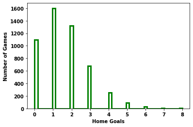

```python
HomeScore = Matches.loc[np.isnan(Matches.match_hometeam_score) == False,"match_hometeam_score"]
a = sns.distplot(HomeScore,kde = False, hist_kws={"histtype": "step", "linewidth": 3,"alpha": 1, "color": "g"},axlabel = "Home Goals")
a.set(ylabel='Number of Games')
plt.show(a)
```

#### 1.b. Away Score Histogram

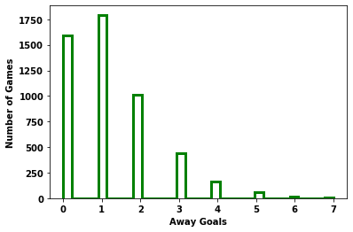

```python
AwayScore = Matches.loc[np.isnan(Matches.match_awayteam_score) == False,"match_awayteam_score"]
b = sns.distplot(AwayScore,kde = False, hist_kws={"histtype": "step", "linewidth": 3,"alpha": 1, "color": "g"},axlabel = "Away Goals")
b.set(ylabel='Number of Games')
plt.show(b)
```

#### 1.c. Home-Away Score Histogram

```python
HomeScore = Matches.loc[(np.isnan(Matches.match_hometeam_score) == False) & (np.isnan(Matches.match_awayteam_score) == False),"match_hometeam_score"]
AwayScore = Matches.loc[(np.isnan(Matches.match_hometeam_score) == False) & (np.isnan(Matches.match_awayteam_score) == False),"match_awayteam_score"]
```

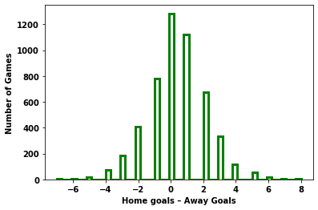

```python
Home_AwayScore = HomeScore - AwayScore
c = sns.distplot(Home_AwayScore,kde = False, hist_kws={"histtype": "step", "linewidth": 3,"alpha": 1, "color": "g"},axlabel = "Home goals – Away Goals")
c.set(ylabel='Number of Games')
plt.show(c)
```

#### 2. Is This Poisson?

```python
HomeScoreMean = HomeScore.mean()
AwayScoreMean = AwayScore.mean()
```

Generating samples drawn from poisson random variable with corresponding means.

```python
HomePoisson = np.random.poisson(lam = HomeScoreMean, size = len(HomeScore))
AwayPoisson = np.random.poisson(lam = AwayScoreMean, size = len(HomeScore))
PlotData = pd.DataFrame(data = {'HomeScore': HomeScore, 'HomePoisson': HomePoisson,'AwayScore': AwayScore, 'AwayPoisson': AwayPoisson})
```

```python
from plotnine import *
```

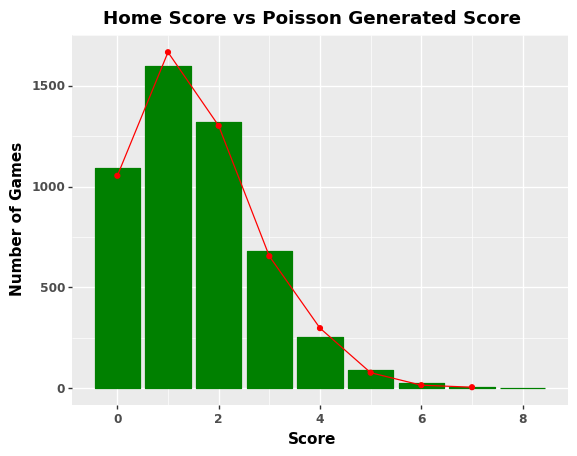

```python
ggplot(PlotData) +  geom_bar(aes(x = "HomeScore"),stat = 'count',colour = "green",fill = "green")+ geom_line(aes(x = "HomePoisson"),stat = 'count',colour = "r") + geom_point(aes(x = "HomePoisson"),stat = 'count',colour = "r") +\
labs(title = "Home Score vs Poisson Generated Score") + xlab("Score") + ylab("Number of Games")
```

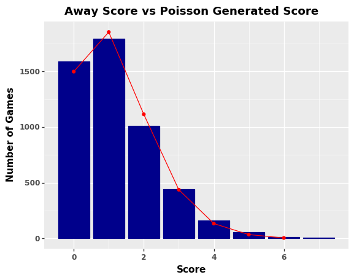

```python
ggplot(PlotData) +  geom_bar(aes(x = "AwayScore"),stat = 'count',colour = "darkblue",fill = "darkblue")+ geom_line(aes(x = "AwayPoisson"),stat = 'count',colour = "r") + geom_point(aes(x = "AwayPoisson"),stat = 'count',colour = "r") +\
labs(title = "Away Score vs Poisson Generated Score") + xlab("Score") + ylab("Number of Games")
```

- Looking at the scores, we can say both home and away scores fit the poisson distribution with corresponding mean values.

## Task 2

```python
Task2Data = Bets.copy()
```

```python
# keep the latest bets of each bookmaker - match pair
Task2Data = Task2Data.merge(how = "inner", right = Task2Data.groupby(["match_id","odd_bookmakers"]).agg({"odd_epoch":"max"}), on = ["match_id","odd_bookmakers","odd_epoch"])
```

```python
# convert epoch to datetime
Task2Data.odd_epoch = pd.to_datetime(Task2Data.odd_epoch, unit='s')
```

- I chose the top 4 bookmakers with highest count in Bets data.

```python
ChosenBookmakers = Task2Data.groupby('odd_bookmakers').count()[["value"]].sort_values(by = "value",ascending = False)[0:4].index
Task2Data = Task2Data[Task2Data.odd_bookmakers.isin(ChosenBookmakers)]
```

```python
# filter variable with odd_* only
Task2Data = Task2Data[Task2Data.variable.isin(['odd_1',"odd_x","odd_2"])]
```

#### 1. Calculate the P(home win), P(tie) and P(away win) by P(x) = 1/odd

```python
Task2Data = Task2Data.drop(columns = ["odd_epoch"])

# pivot of data
Task2Data["Key"] = Task2Data["odd_bookmakers"] + "-" + Task2Data["match_id"].map(str)
Task2Data = Task2Data[["Key","odd_bookmakers","match_id"]].drop_duplicates().merge(right = Task2Data.pivot(index = "Key",columns = "variable", values = "value"), how = "inner", on = "Key").drop(columns = "Key")
```

```python
Task2Data["prob_1"] = 1/Task2Data["odd_1"]
Task2Data["prob_x"] = 1/Task2Data["odd_x"]
Task2Data["prob_2"] = 1/Task2Data["odd_2"]
```

```python
# iff any of odds is 0, then corresponding probability will be inf. So I change those probabilities to 0.0001
Task2Data.loc[Task2Data.odd_1 == 0,"prob_1"] = 0.0001
Task2Data.loc[Task2Data.odd_x == 0,"prob_x"] = 0.0001
Task2Data.loc[Task2Data.odd_2 == 0,"prob_2"] = 0.0001
```

```python
Task2Data.head()
```

|  | odd_bookmakers | match_id | odd_1 | odd_2 | odd_x | prob_1 | prob_x | prob_2 |
| --- | --- | --- | --- | --- | --- | --- | --- | --- |
| 0 | 18bet | 151780 | 2.17 | 3.32 | 3.12 | 0.460829 | 0.320513 | 0.301205 |
| 1 | 1xBet | 151780 | 2.20 | 3.88 | 3.24 | 0.454545 | 0.308642 | 0.257732 |
| 2 | bet365 | 151780 | 2.20 | 3.90 | 3.20 | 0.454545 | 0.312500 | 0.256410 |
| 3 | Marathonbet | 151780 | 2.19 | 3.90 | 3.26 | 0.456621 | 0.306748 | 0.256410 |
| 4 | 18bet | 151781 | 2.78 | 2.44 | 3.19 | 0.359712 | 0.313480 | 0.409836 |

#### 2. Normalization of Probabilities

```python
Task2Data["prob_sum"] = Task2Data["prob_1"] + Task2Data["prob_x"] + Task2Data["prob_2"]
Task2Data["norm_prob_1"] = Task2Data["prob_1"] / Task2Data["prob_sum"]
Task2Data["norm_prob_x"] = Task2Data["prob_x"] / Task2Data["prob_sum"]
Task2Data["norm_prob_2"] = Task2Data["prob_2"] / Task2Data["prob_sum"]
Task2Data["phome_paway"] = Task2Data["norm_prob_1"] - Task2Data["norm_prob_2"]
```

```python
Task2Data.head()
```

|  | odd_bookmakers | match_id | odd_1 | odd_2 | odd_x | prob_1 | prob_x | prob_2 | prob_sum | norm_prob_1 | norm_prob_x | norm_prob_2 | phome_paway |
| --- | --- | --- | --- | --- | --- | --- | --- | --- | --- | --- | --- | --- | --- |
| 0 | 18bet | 151780 | 2.17 | 3.32 | 3.12 | 0.460829 | 0.320513 | 0.301205 | 1.082547 | 0.425690 | 0.296073 | 0.278237 | 0.147453 |
| 1 | 1xBet | 151780 | 2.20 | 3.88 | 3.24 | 0.454545 | 0.308642 | 0.257732 | 1.020919 | 0.445231 | 0.302318 | 0.252451 | 0.192781 |
| 2 | bet365 | 151780 | 2.20 | 3.90 | 3.20 | 0.454545 | 0.312500 | 0.256410 | 1.023456 | 0.444128 | 0.305338 | 0.250534 | 0.193594 |
| 3 | Marathonbet | 151780 | 2.19 | 3.90 | 3.26 | 0.456621 | 0.306748 | 0.256410 | 1.019780 | 0.447764 | 0.300799 | 0.251437 | 0.196327 |
| 4 | 18bet | 151781 | 2.78 | 2.44 | 3.19 | 0.359712 | 0.313480 | 0.409836 | 1.083028 | 0.332136 | 0.289447 | 0.378417 | -0.046281 |

#### 3. Plotting P(home win) - P(away win)

```python
# creating bins from -1 to 1 with 0.05 step
bins = np.arange(-1.0, 1.05, 0.05)

# in order to plot correctly (x axis will be numerical), i calculated the mid point of each bin
CutMids = pd.DataFrame(data = {'bin_ph_pa' : pd.cut(x = bins, bins = bins).categories.astype(str), 'midpoints' : np.arange(-0.975,1.025,0.05)})

# bins of p(home win) - p(away win)
Task2Data["bin_ph_pa"] = pd.cut(x = Task2Data.phome_paway, bins = bins).astype(str)

# join numerical mid points to bins
Task2Data = Task2Data.merge(right = CutMids, on = "bin_ph_pa", how = "left")
```

```python
# bring match results (1 if draw, else 0 -- so that we can sum them up to count # of draws)
# only finished matches
Draws = Matches.loc[Matches.match_status == 'Finished',["match_id","match_hometeam_score","match_awayteam_score"]]
Draws["IsDraw"] = np.where(Draws.match_hometeam_score == Draws.match_awayteam_score,1,0)
Draws = Draws[['match_id','IsDraw']]
Task2Data = Task2Data.merge(right = Draws, how = "inner", on = "match_id")
```

```python
# calculate number of matches and number of draws for each bin
Task2Data["bin_match_count"] = Task2Data.groupby(['bin_ph_pa'])["bin_ph_pa"].transform('count')
Task2Data["bin_draw_count"] = Task2Data.groupby(['bin_ph_pa'])["IsDraw"].transform('sum')

# calculate probability of draw by # of draw / # of matches
Task2Data["bin_prob_x"] = Task2Data["bin_draw_count"] / Task2Data["bin_match_count"]
```

```python
Task2Data.head()
```

|  | odd_bookmakers | match_id | odd_1 | odd_2 | odd_x | prob_1 | prob_x | prob_2 | prob_sum | norm_prob_1 | norm_prob_x | norm_prob_2 | phome_paway | bin_ph_pa | midpoints | IsDraw | bin_match_count | bin_draw_count | bin_prob_x |
| --- | --- | --- | --- | --- | --- | --- | --- | --- | --- | --- | --- | --- | --- | --- | --- | --- | --- | --- | --- |
| 0 | 18bet | 151780 | 2.17 | 3.32 | 3.12 | 0.460829 | 0.320513 | 0.301205 | 1.082547 | 0.425690 | 0.296073 | 0.278237 | 0.147453 | (0.1, 0.15] | 0.125 | 0 | 534 | 185 | 0.346442 |
| 1 | 1xBet | 151780 | 2.20 | 3.88 | 3.24 | 0.454545 | 0.308642 | 0.257732 | 1.020919 | 0.445231 | 0.302318 | 0.252451 | 0.192781 | (0.15, 0.2] | 0.175 | 0 | 595 | 174 | 0.292437 |
| 2 | bet365 | 151780 | 2.20 | 3.90 | 3.20 | 0.454545 | 0.312500 | 0.256410 | 1.023456 | 0.444128 | 0.305338 | 0.250534 | 0.193594 | (0.15, 0.2] | 0.175 | 0 | 595 | 174 | 0.292437 |
| 3 | Marathonbet | 151780 | 2.19 | 3.90 | 3.26 | 0.456621 | 0.306748 | 0.256410 | 1.019780 | 0.447764 | 0.300799 | 0.251437 | 0.196327 | (0.15, 0.2] | 0.175 | 0 | 595 | 174 | 0.292437 |
| 4 | 18bet | 151781 | 2.78 | 2.44 | 3.19 | 0.359712 | 0.313480 | 0.409836 | 1.083028 | 0.332136 | 0.289447 | 0.378417 | -0.046281 | (-0.05, 8.88e-16] | -0.025 | 0 | 430 | 116 | 0.269767 |

```python
p_task2 = ggplot(data = Task2Data) + geom_point(aes(x = "phome_paway",y = "norm_prob_x"),colour = "blue",size = 0.2) + geom_point(aes(x = "midpoints",y = "bin_prob_x"),colour = "red",size = 1) + \
xlab("P(Home Win) − P(Away Win)") + ylab("P(Draw)") + scale_x_continuous(breaks = [-1,-0.75,-0.5,-0.25,0,0.25,0.5,0.75,1]) + ylim(0,0.5)
display(p_task2)
```

[output not shown]

- Bins where P(Home Win) − P(Away Win) is around (-0.3,-0.2) might have potential to earn money in the long run. Since occurence rate of draws in those bins, higher than the bookmakers odds.

#### 4. Comment on 4 Bookmakers

```python
ChosenBookmakers
```

```
Index(['1xBet', '18bet', 'bet365', 'Marathonbet'], dtype='object', name='odd_bookmakers')
```

###### Bookmaker: 1xBet

```python
bookmaker = "1xBet"
SingleBookmakerData = Task2Data.loc[Task2Data.odd_bookmakers == "1xBet"].copy()

SingleBookmakerData["bin_match_count"] = SingleBookmakerData.groupby(['bin_ph_pa'])["bin_ph_pa"].transform('count')
SingleBookmakerData["bin_draw_count"] = SingleBookmakerData.groupby(['bin_ph_pa'])["IsDraw"].transform('sum')

# calculate probability of draw by # of draw / # of matches
SingleBookmakerData["bin_prob_x"] = SingleBookmakerData["bin_draw_count"] / SingleBookmakerData["bin_match_count"]

p_1xBet = ggplot(data = SingleBookmakerData) + geom_point(aes(x = "phome_paway",y = "norm_prob_x"),colour = "blue",size = 0.2) + geom_point(aes(x = "midpoints",y = "bin_prob_x"),colour = "red",size = 1) + \
xlab("P(Home Win) − P(Away Win)") + ylab("P(Draw)") + scale_x_continuous(breaks = [-1,-0.75,-0.5,-0.25,0,0.25,0.5,0.75,1]) + labs(title = "Bookmaker: 1xBet") + ylim(0,0.5)
p_1xBet
```

[output not shown]

###### Bookmaker: 18bet

```python
SingleBookmakerData = Task2Data.loc[Task2Data.odd_bookmakers == "18bet"].copy()

SingleBookmakerData["bin_match_count"] = SingleBookmakerData.groupby(['bin_ph_pa'])["bin_ph_pa"].transform('count')
SingleBookmakerData["bin_draw_count"] = SingleBookmakerData.groupby(['bin_ph_pa'])["IsDraw"].transform('sum')

# calculate probability of draw by # of draw / # of matches
SingleBookmakerData["bin_prob_x"] = SingleBookmakerData["bin_draw_count"] / SingleBookmakerData["bin_match_count"]

p_18bet = ggplot(data = SingleBookmakerData) + geom_point(aes(x = "phome_paway",y = "norm_prob_x"),colour = "blue",size = 0.2) + geom_point(aes(x = "midpoints",y = "bin_prob_x"),colour = "red",size = 1) + \
xlab("P(Home Win) − P(Away Win)") + ylab("P(Draw)") + scale_x_continuous(breaks = [-1,-0.75,-0.5,-0.25,0,0.25,0.5,0.75,1]) + labs(title = "Bookmaker: 18bet") + ylim(0,0.5)
p_18bet
```

[output not shown]

###### Bookmaker: bet365

```python
SingleBookmakerData = Task2Data.loc[Task2Data.odd_bookmakers == "bet365"].copy()

SingleBookmakerData["bin_match_count"] = SingleBookmakerData.groupby(['bin_ph_pa'])["bin_ph_pa"].transform('count')
SingleBookmakerData["bin_draw_count"] = SingleBookmakerData.groupby(['bin_ph_pa'])["IsDraw"].transform('sum')

# calculate probability of draw by # of draw / # of matches
SingleBookmakerData["bin_prob_x"] = SingleBookmakerData["bin_draw_count"] / SingleBookmakerData["bin_match_count"]

p_bet365 = ggplot(data = SingleBookmakerData) + geom_point(aes(x = "phome_paway",y = "norm_prob_x"),colour = "blue",size = 0.2) + geom_point(aes(x = "midpoints",y = "bin_prob_x"),colour = "red",size = 1) + \
xlab("P(Home Win) − P(Away Win)") + ylab("P(Draw)") + scale_x_continuous(breaks = [-1,-0.75,-0.5,-0.25,0,0.25,0.5,0.75,1]) + labs(title = "Bookmaker: bet365") + ylim(0,0.5)
p_bet365
```

[output not shown]

###### Bookmaker: Marathonbet

```python
SingleBookmakerData = Task2Data.loc[Task2Data.odd_bookmakers == "Marathonbet"].copy()

SingleBookmakerData["bin_match_count"] = SingleBookmakerData.groupby(['bin_ph_pa'])["bin_ph_pa"].transform('count')
SingleBookmakerData["bin_draw_count"] = SingleBookmakerData.groupby(['bin_ph_pa'])["IsDraw"].transform('sum')

# calculate probability of draw by # of draw / # of matches
SingleBookmakerData["bin_prob_x"] = SingleBookmakerData["bin_draw_count"] / SingleBookmakerData["bin_match_count"]

p_Marathonbet = ggplot(data = SingleBookmakerData) + geom_point(aes(x = "phome_paway",y = "norm_prob_x"),colour = "blue",size = 0.2) + geom_point(aes(x = "midpoints",y = "bin_prob_x"),colour = "red",size = 1) + \
xlab("P(Home Win) − P(Away Win)") + ylab("P(Draw)") + scale_x_continuous(breaks = [-1,-0.75,-0.5,-0.25,0,0.25,0.5,0.75,1]) + labs(title = "Bookmaker: Marathonbet") + ylim(0,0.5)
p_Marathonbet
```

[output not shown]

## Task 3

#### Case 1

- I considered the matches of which result changed with the latest goal scored after 85.

```python
# Scores after 85th min
Case1Data = Goals.loc[Goals.time > '85'].copy()

# latest score of the game
Case1Data = Case1Data.sort_values(["match_id","time"],ascending = [True,False])
Case1Data["rowno"] = Case1Data.groupby("match_id").cumcount()+1
Case1Data = Case1Data.loc[Case1Data.rowno == 1]
```

```python
# take last goal scored for each match
Case1Data["scoring_side"] = np.where(pd.isnull(Case1Data.home_scorer),"Away","Home")
Case1Data = Case1Data[["match_id","scoring_side"]]
```

```python
# merge matches and goal data
# I considered the finished matches with absolute diff of home - away goals less than or equal to 1
Case1Data = Matches.loc[(Matches.match_status == "Finished") & (abs(Matches.match_hometeam_score - Matches.match_awayteam_score) <= 1)].\
merge(right = Case1Data, how = "inner",on = "match_id")
```

```python
Case1Matches = Case1Data.loc[(Case1Data.match_hometeam_score == Case1Data.match_awayteam_score) | \
              ((Case1Data.match_hometeam_score > Case1Data.match_awayteam_score) & (Case1Data.scoring_side == "Home")) | \
              ((Case1Data.match_hometeam_score < Case1Data.match_awayteam_score) & (Case1Data.scoring_side == "Away"))\
             ,"match_id"]
# if game became tie with last goal
# if home team won with last goal
# if away team won with last goal
```

```python
# number of unique matches in Task 2 data
len(Task2Data.match_id.unique())
```

```
2192
```

```python
# number of unique matches which fits to our case
len(Case1Matches)
```

```
457
```

```python
Case1Data = Task2Data.loc[~(Task2Data.match_id.isin(Case1Matches))].copy()
```

```python
# number of unique matches left after removing selected matches
len(Case1Data.match_id.unique())
```

```
1980
```

```python
# calculate number of matches and number of draws for each bin
Case1Data["bin_match_count"] = Case1Data.groupby(['bin_ph_pa'])["bin_ph_pa"].transform('count')
Case1Data["bin_draw_count"] = Case1Data.groupby(['bin_ph_pa'])["IsDraw"].transform('sum')

# calculate probability of draw by # of draw / # of matches
Case1Data["bin_prob_x"] = Case1Data["bin_draw_count"] / Case1Data["bin_match_count"]
```

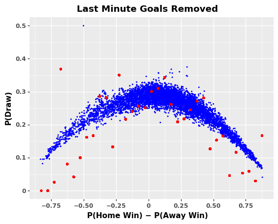

```python
display(p_task2)
p_task3case1 = ggplot(data = Case1Data) + geom_point(aes(x = "phome_paway",y = "norm_prob_x"),colour = "blue",size = 0.2) + geom_point(aes(x = "midpoints",y = "bin_prob_x"),colour = "red",size = 1) + \
xlab("P(Home Win) − P(Away Win)") + ylab("P(Draw)") + scale_x_continuous(breaks = [-1,-0.75,-0.5,-0.25,0,0.25,0.5,0.75,1]) + ylim(0,0.5) + labs(title = "Last Minute Goals Removed")
display(p_task3case1)
```

- When we remove the last minute goals, occurence of mathes resulted as draw has decreased. Bookmakers's odd_x settings looks reasonable for them when last minute accidents do not occur.

```python
ChosenBookmakers
```

```
Index(['1xBet', '18bet', 'bet365', 'Marathonbet'], dtype='object', name='odd_bookmakers')
```

###### Bookmaker: 1xBet

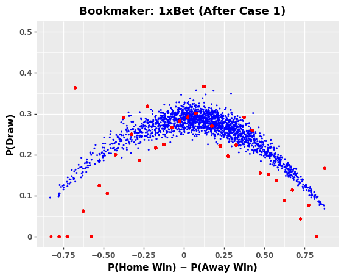

```python
SingleBookmakerData = Case1Data.loc[Task2Data.odd_bookmakers == "1xBet"].copy()

SingleBookmakerData["bin_match_count"] = SingleBookmakerData.groupby(['bin_ph_pa'])["bin_ph_pa"].transform('count')
SingleBookmakerData["bin_draw_count"] = SingleBookmakerData.groupby(['bin_ph_pa'])["IsDraw"].transform('sum')

# calculate probability of draw by # of draw / # of matches
SingleBookmakerData["bin_prob_x"] = SingleBookmakerData["bin_draw_count"] / SingleBookmakerData["bin_match_count"]

p_1xBet_case1 = ggplot(data = SingleBookmakerData) + geom_point(aes(x = "phome_paway",y = "norm_prob_x"),colour = "blue",size = 0.2) + geom_point(aes(x = "midpoints",y = "bin_prob_x"),colour = "red",size = 1) + \
xlab("P(Home Win) − P(Away Win)") + ylab("P(Draw)") + scale_x_continuous(breaks = [-1,-0.75,-0.5,-0.25,0,0.25,0.5,0.75,1]) + labs(title = "Bookmaker: 1xBet (After Case 1)") + ylim(0,0.5)
display(p_1xBet)
display(p_1xBet_case1)
```

###### Bookmaker: 18bet

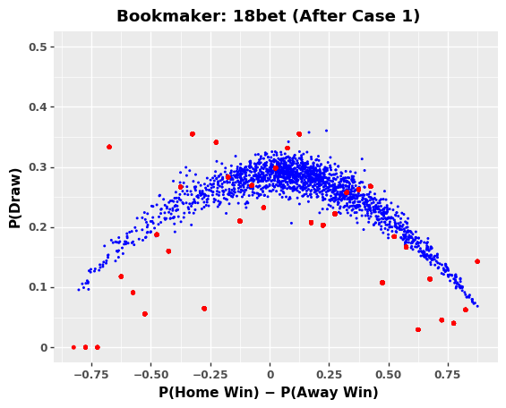

```python
SingleBookmakerData = Case1Data.loc[Task2Data.odd_bookmakers == "18bet"].copy()

SingleBookmakerData["bin_match_count"] = SingleBookmakerData.groupby(['bin_ph_pa'])["bin_ph_pa"].transform('count')
SingleBookmakerData["bin_draw_count"] = SingleBookmakerData.groupby(['bin_ph_pa'])["IsDraw"].transform('sum')

# calculate probability of draw by # of draw / # of matches
SingleBookmakerData["bin_prob_x"] = SingleBookmakerData["bin_draw_count"] / SingleBookmakerData["bin_match_count"]

p_18bet_case1 = ggplot(data = SingleBookmakerData) + geom_point(aes(x = "phome_paway",y = "norm_prob_x"),colour = "blue",size = 0.2) + geom_point(aes(x = "midpoints",y = "bin_prob_x"),colour = "red",size = 1) + \
xlab("P(Home Win) − P(Away Win)") + ylab("P(Draw)") + scale_x_continuous(breaks = [-1,-0.75,-0.5,-0.25,0,0.25,0.5,0.75,1]) + labs(title = "Bookmaker: 18bet (After Case 1)") + ylim(0,0.5)
display(p_18bet)
display(p_18bet_case1)
```

###### Bookmaker: bet365

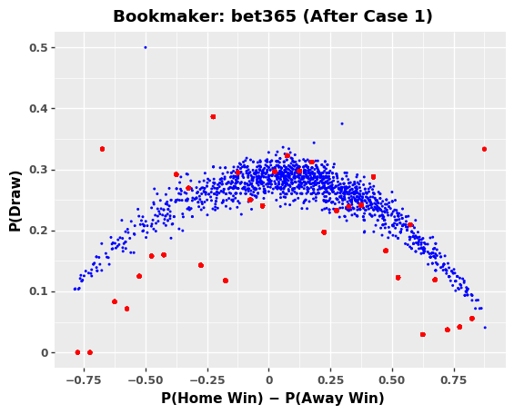

```python
SingleBookmakerData = Case1Data.loc[Task2Data.odd_bookmakers == "bet365"].copy()

SingleBookmakerData["bin_match_count"] = SingleBookmakerData.groupby(['bin_ph_pa'])["bin_ph_pa"].transform('count')
SingleBookmakerData["bin_draw_count"] = SingleBookmakerData.groupby(['bin_ph_pa'])["IsDraw"].transform('sum')

# calculate probability of draw by # of draw / # of matches
SingleBookmakerData["bin_prob_x"] = SingleBookmakerData["bin_draw_count"] / SingleBookmakerData["bin_match_count"]

p_bet365_case1 = ggplot(data = SingleBookmakerData) + geom_point(aes(x = "phome_paway",y = "norm_prob_x"),colour = "blue",size = 0.2) + geom_point(aes(x = "midpoints",y = "bin_prob_x"),colour = "red",size = 1) + \
xlab("P(Home Win) − P(Away Win)") + ylab("P(Draw)") + scale_x_continuous(breaks = [-1,-0.75,-0.5,-0.25,0,0.25,0.5,0.75,1]) + labs(title = "Bookmaker: bet365 (After Case 1)") + ylim(0,0.5)
display(p_bet365)
display(p_bet365_case1)
```

###### Bookmaker: Marathonbet

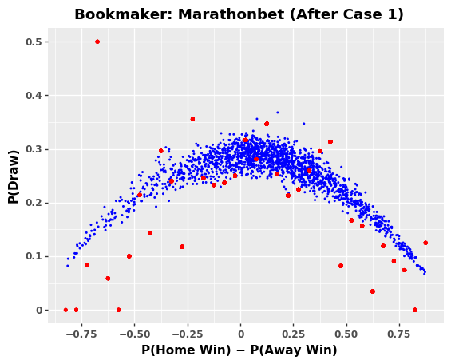

```python
SingleBookmakerData = Case1Data.loc[Task2Data.odd_bookmakers == "Marathonbet"].copy()

SingleBookmakerData["bin_match_count"] = SingleBookmakerData.groupby(['bin_ph_pa'])["bin_ph_pa"].transform('count')
SingleBookmakerData["bin_draw_count"] = SingleBookmakerData.groupby(['bin_ph_pa'])["IsDraw"].transform('sum')

# calculate probability of draw by # of draw / # of matches
SingleBookmakerData["bin_prob_x"] = SingleBookmakerData["bin_draw_count"] / SingleBookmakerData["bin_match_count"]

p_Marathonbet_case1 = ggplot(data = SingleBookmakerData) + geom_point(aes(x = "phome_paway",y = "norm_prob_x"),colour = "blue",size = 0.2) + geom_point(aes(x = "midpoints",y = "bin_prob_x"),colour = "red",size = 1) + \
xlab("P(Home Win) − P(Away Win)") + ylab("P(Draw)") + scale_x_continuous(breaks = [-1,-0.75,-0.5,-0.25,0,0.25,0.5,0.75,1]) + labs(title = "Bookmaker: Marathonbet (After Case 1)") + ylim(0,0.5)
display(p_Marathonbet)
display(p_Marathonbet_case1)
```

#### Case 2

- I considered the matches which red card occured in first 30 mins

```python
Case2Matches = Booking.loc[(Booking.card == "red card") & (Booking.time <= '30'),"match_id"].unique()
```

```python
# number of unique matches in Task 2 data
len(Task2Data.match_id.unique())
```

```
2192
```

```python
# number of unique matches which fits to our case
len(Case2Matches)
```

```
68
```

```python
Case2Data = Task2Data.loc[~(Task2Data.match_id.isin(Case2Matches))].copy()
```

```python
# number of unique matches left after removing selected matches
len(Case2Data.match_id.unique())
```

```
2154
```

```python
# calculate number of matches and number of draws for each bin
Case2Data["bin_match_count"] = Case2Data.groupby(['bin_ph_pa'])["bin_ph_pa"].transform('count')
Case2Data["bin_draw_count"] = Case2Data.groupby(['bin_ph_pa'])["IsDraw"].transform('sum')

# calculate probability of draw by # of draw / # of matches
Case2Data["bin_prob_x"] = Case2Data["bin_draw_count"] / Case2Data["bin_match_count"]
```

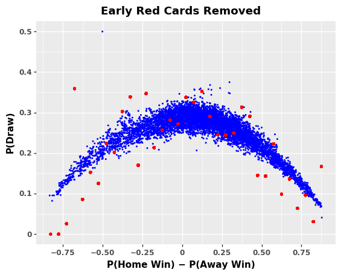

```python
display(p_task2)
p_task3case2 = ggplot(data = Case2Data) + geom_point(aes(x = "phome_paway",y = "norm_prob_x"),colour = "blue",size = 0.2) + geom_point(aes(x = "midpoints",y = "bin_prob_x"),colour = "red",size = 1) + \
xlab("P(Home Win) − P(Away Win)") + ylab("P(Draw)") + scale_x_continuous(breaks = [-1,-0.75,-0.5,-0.25,0,0.25,0.5,0.75,1]) + ylim(0,0.5) + labs(title = "Early Red Cards Removed")
display(p_task3case2)
```

- Removing the games with the early red cards seem like less effective than the previous case. There is slightly a fall on the red dots but considering the case 1 its too little. It might be due to number of matches which removed from the data.

###### Bookmaker: 1xBet

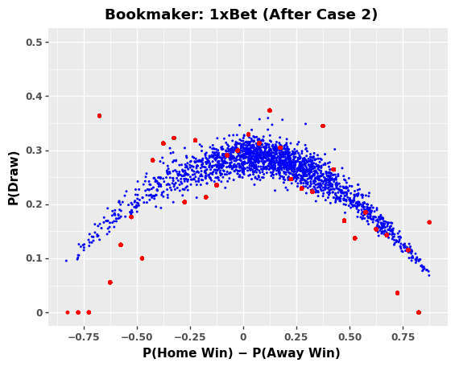

```python
SingleBookmakerData = Case2Data.loc[Task2Data.odd_bookmakers == "1xBet"].copy()

SingleBookmakerData["bin_match_count"] = SingleBookmakerData.groupby(['bin_ph_pa'])["bin_ph_pa"].transform('count')
SingleBookmakerData["bin_draw_count"] = SingleBookmakerData.groupby(['bin_ph_pa'])["IsDraw"].transform('sum')

# calculate probability of draw by # of draw / # of matches
SingleBookmakerData["bin_prob_x"] = SingleBookmakerData["bin_draw_count"] / SingleBookmakerData["bin_match_count"]

p_1xBet_case2 = ggplot(data = SingleBookmakerData) + geom_point(aes(x = "phome_paway",y = "norm_prob_x"),colour = "blue",size = 0.2) + geom_point(aes(x = "midpoints",y = "bin_prob_x"),colour = "red",size = 1) + \
xlab("P(Home Win) − P(Away Win)") + ylab("P(Draw)") + scale_x_continuous(breaks = [-1,-0.75,-0.5,-0.25,0,0.25,0.5,0.75,1]) + labs(title = "Bookmaker: 1xBet (After Case 2)") + ylim(0,0.5)
display(p_1xBet)
display(p_1xBet_case2)
```

###### Bookmaker: 18bet

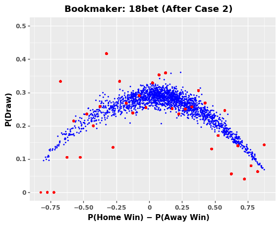

```python
SingleBookmakerData = Case2Data.loc[Task2Data.odd_bookmakers == "18bet"].copy()

SingleBookmakerData["bin_match_count"] = SingleBookmakerData.groupby(['bin_ph_pa'])["bin_ph_pa"].transform('count')
SingleBookmakerData["bin_draw_count"] = SingleBookmakerData.groupby(['bin_ph_pa'])["IsDraw"].transform('sum')

# calculate probability of draw by # of draw / # of matches
SingleBookmakerData["bin_prob_x"] = SingleBookmakerData["bin_draw_count"] / SingleBookmakerData["bin_match_count"]

p_18bet_case2 = ggplot(data = SingleBookmakerData) + geom_point(aes(x = "phome_paway",y = "norm_prob_x"),colour = "blue",size = 0.2) + geom_point(aes(x = "midpoints",y = "bin_prob_x"),colour = "red",size = 1) + \
xlab("P(Home Win) − P(Away Win)") + ylab("P(Draw)") + scale_x_continuous(breaks = [-1,-0.75,-0.5,-0.25,0,0.25,0.5,0.75,1]) + labs(title = "Bookmaker: 18bet (After Case 2)") + ylim(0,0.5)
display(p_18bet)
display(p_18bet_case2)
```

###### Bookmaker: bet365

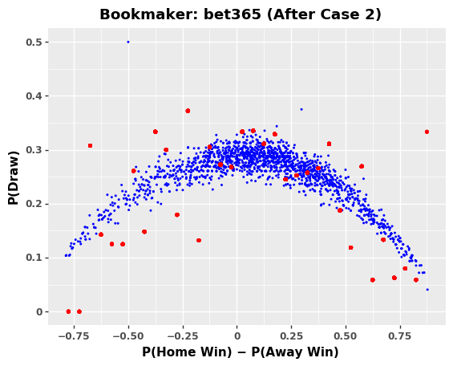

```python
SingleBookmakerData = Case2Data.loc[Task2Data.odd_bookmakers == "bet365"].copy()

SingleBookmakerData["bin_match_count"] = SingleBookmakerData.groupby(['bin_ph_pa'])["bin_ph_pa"].transform('count')
SingleBookmakerData["bin_draw_count"] = SingleBookmakerData.groupby(['bin_ph_pa'])["IsDraw"].transform('sum')

# calculate probability of draw by # of draw / # of matches
SingleBookmakerData["bin_prob_x"] = SingleBookmakerData["bin_draw_count"] / SingleBookmakerData["bin_match_count"]

p_bet365_case2 = ggplot(data = SingleBookmakerData) + geom_point(aes(x = "phome_paway",y = "norm_prob_x"),colour = "blue",size = 0.2) + geom_point(aes(x = "midpoints",y = "bin_prob_x"),colour = "red",size = 1) + \
xlab("P(Home Win) − P(Away Win)") + ylab("P(Draw)") + scale_x_continuous(breaks = [-1,-0.75,-0.5,-0.25,0,0.25,0.5,0.75,1]) + labs(title = "Bookmaker: bet365 (After Case 2)") + ylim(0,0.5)
display(p_bet365)
display(p_bet365_case2)
```

###### Bookmaker: Marathonbet

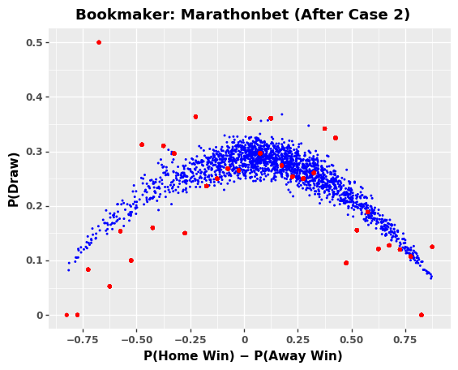

```python
SingleBookmakerData = Case2Data.loc[Task2Data.odd_bookmakers == "Marathonbet"].copy()

SingleBookmakerData["bin_match_count"] = SingleBookmakerData.groupby(['bin_ph_pa'])["bin_ph_pa"].transform('count')
SingleBookmakerData["bin_draw_count"] = SingleBookmakerData.groupby(['bin_ph_pa'])["IsDraw"].transform('sum')

# calculate probability of draw by # of draw / # of matches
SingleBookmakerData["bin_prob_x"] = SingleBookmakerData["bin_draw_count"] / SingleBookmakerData["bin_match_count"]

p_Marathonbet_case2 = ggplot(data = SingleBookmakerData) + geom_point(aes(x = "phome_paway",y = "norm_prob_x"),colour = "blue",size = 0.2) + geom_point(aes(x = "midpoints",y = "bin_prob_x"),colour = "red",size = 1) + \
xlab("P(Home Win) − P(Away Win)") + ylab("P(Draw)") + scale_x_continuous(breaks = [-1,-0.75,-0.5,-0.25,0,0.25,0.5,0.75,1]) + labs(title = "Bookmaker: Marathonbet (After Case 2)") + ylim(0,0.5)
display(p_Marathonbet)
display(p_Marathonbet_case2)
```